# Risk Factor Analysis

## Outcome Variable

**Outcome Variable:** haz

## Predictor Variables

**Intervention Variable:** hhwealth_quart

**Adjustment Set:**

- arm
- sex
- W_mage
- meducyrs
- feducyrs
- W_gagebrth
- W_birthwt
- W_birthlen
- W_nchldlt5
- W_parity
- delta_W_mage
- delta_meducyrs
- delta_feducyrs
- delta_W_gagebrth
- delta_W_birthwt
- delta_W_birthlen
- delta_W_nchldlt5
- delta_W_parity

## Stratifying Variables

The analysis was stratified on these variable(s):

- agecat

## Data Summary

| agecat | hhwealth_quart | n_cell | n |
| --- | --- | --- | --- |
| Birth | Wealth Q4 | 5663 | 25049 |
| Birth | Wealth Q1 | 6444 | 25049 |
| Birth | Wealth Q2 | 6456 | 25049 |
| Birth | Wealth Q3 | 6486 | 25049 |
| 6 months | Wealth Q4 | 8316 | 30585 |
| 6 months | Wealth Q1 | 7088 | 30585 |
| 6 months | Wealth Q2 | 7266 | 30585 |
| 6 months | Wealth Q3 | 7915 | 30585 |
| 24 months | Wealth Q4 | 5234 | 19800 |
| 24 months | Wealth Q1 | 4596 | 19800 |
| 24 months | Wealth Q2 | 4745 | 19800 |
| 24 months | Wealth Q3 | 5225 | 19800 |

The following strata were considered:

- agecat: 24 months
- agecat: 6 months
- agecat: Birth

## Methods Detail

We’re interested in the causal parameters $E[Y_a]$ for all values of $a \in \mathcal{A}$. These parameters represent the mean outcome if, possibly contrary to fact, we intervened to set all units to have $A=a$. Under the randomization and positivity assumptions, these are identified by the statistical parameters $\psi_a=E_W[E_{Y|A,W}(Y|A=a,W)]$. In addition, we’re interested in the mean of $Y$, $E[Y]$ under no intervention (the observed mean). We will estimate these parameters by using SuperLearner to fit the relevant likelihood factors – $E_{Y|A,W}(Y|A=a,W)$ and $p(A=a|W)$, and then updating our likelihood fit using a joint TMLE.

For unadjusted analyses ($W=\{\}$), initial likelihoods were estimated using Lrnr_glm to estimate the simple $E(Y|A)$ and Lrnr_mean to estimate $p(A)$. For adjusted analyses, a small library containing Lrnr_glmnet, Lrnr_xgboost, and Lrnr_mean was used.

Having estimated these parameters, we will then use the delta method to estimate relative risks and attributable risks relative to a prespecified baseline level of $A$.

# Results Detail

## Results Plots

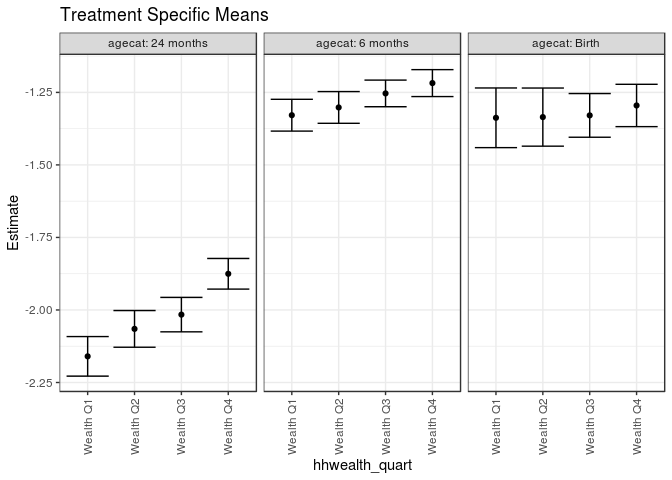

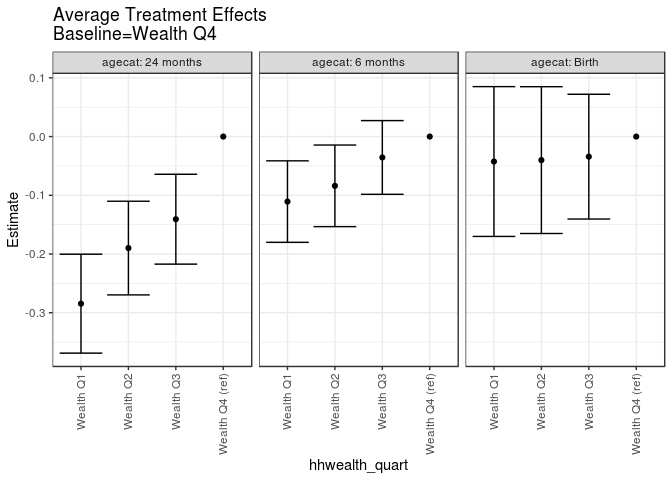

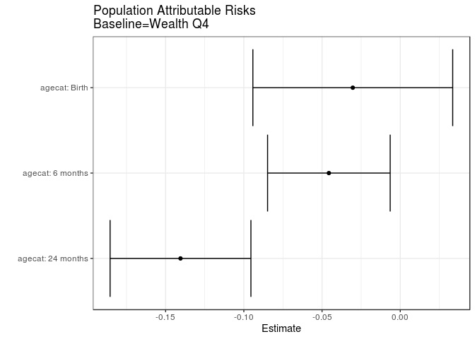

## Results Table

### Parameter: TSM

| agecat | intervention_level | baseline_level | estimate | ci_lower | ci_upper |
| --- | --- | --- | --- | --- | --- |
| Birth | Wealth Q4 | NA | -1.295064 | -1.368068 | -1.222061 |
| Birth | Wealth Q1 | NA | -1.337586 | -1.440427 | -1.234745 |
| Birth | Wealth Q2 | NA | -1.335147 | -1.435356 | -1.234937 |
| Birth | Wealth Q3 | NA | -1.329273 | -1.404631 | -1.253914 |
| 6 months | Wealth Q4 | NA | -1.217928 | -1.264320 | -1.171535 |
| 6 months | Wealth Q1 | NA | -1.328651 | -1.383422 | -1.273881 |
| 6 months | Wealth Q2 | NA | -1.301849 | -1.356565 | -1.247133 |
| 6 months | Wealth Q3 | NA | -1.253504 | -1.299418 | -1.207590 |
| 24 months | Wealth Q4 | NA | -1.875266 | -1.928074 | -1.822458 |
| 24 months | Wealth Q1 | NA | -2.159844 | -2.228067 | -2.091622 |
| 24 months | Wealth Q2 | NA | -2.065155 | -2.128420 | -2.001890 |
| 24 months | Wealth Q3 | NA | -2.016004 | -2.075373 | -1.956635 |

### Parameter: E(Y)

| agecat | intervention_level | baseline_level | estimate | ci_lower | ci_upper |
| --- | --- | --- | --- | --- | --- |
| Birth | NA | NA | -1.325420 | -1.358764 | -1.292075 |
| 6 months | NA | NA | -1.263565 | -1.289192 | -1.237938 |
| 24 months | NA | NA | -2.015746 | -2.046052 | -1.985440 |

### Parameter: ATE

| agecat | intervention_level | baseline_level | estimate | ci_lower | ci_upper |
| --- | --- | --- | --- | --- | --- |
| Birth | Wealth Q4 | Wealth Q4 | 0.0000000 | 0.0000000 | 0.0000000 |
| Birth | Wealth Q1 | Wealth Q4 | -0.0425211 | -0.1700643 | 0.0850221 |
| Birth | Wealth Q2 | Wealth Q4 | -0.0400822 | -0.1650517 | 0.0848874 |
| Birth | Wealth Q3 | Wealth Q4 | -0.0342080 | -0.1404371 | 0.0720210 |
| 6 months | Wealth Q4 | Wealth Q4 | 0.0000000 | 0.0000000 | 0.0000000 |
| 6 months | Wealth Q1 | Wealth Q4 | -0.1107235 | -0.1801432 | -0.0413038 |
| 6 months | Wealth Q2 | Wealth Q4 | -0.0839213 | -0.1534034 | -0.0144392 |
| 6 months | Wealth Q3 | Wealth Q4 | -0.0355760 | -0.0983448 | 0.0271927 |
| 24 months | Wealth Q4 | Wealth Q4 | 0.0000000 | 0.0000000 | 0.0000000 |
| 24 months | Wealth Q1 | Wealth Q4 | -0.2845780 | -0.3688299 | -0.2003262 |
| 24 months | Wealth Q2 | Wealth Q4 | -0.1898885 | -0.2696172 | -0.1101599 |
| 24 months | Wealth Q3 | Wealth Q4 | -0.1407377 | -0.2172456 | -0.0642297 |

### Parameter: PAR

| agecat | intervention_level | baseline_level | estimate | ci_lower | ci_upper |
| --- | --- | --- | --- | --- | --- |
| Birth | Wealth Q4 | NA | -0.0303554 | -0.0942246 | 0.0335139 |
| 6 months | Wealth Q4 | NA | -0.0456372 | -0.0848276 | -0.0064468 |
| 24 months | Wealth Q4 | NA | -0.1404796 | -0.1854860 | -0.0954732 |